# Uilisation GitHub

## Introduction

Git is a version management software. The idea is to save the different changements made on a projet, and create an historic of it. To do so, between two saved versions, changements will be added on git with the “add” command, and a little comment on the modification will be joint with the “commit” command as explained later.

Github is a remote service, to save the different git versions. It also enable several people to work on a same project. To use it, you have to :  
* create a Git hub account * make a link (ssh) between your computer and your account * create or join a repository * use the “push” and “pull” commands to share your work and get the advanced from others.

To have a global idea, to use git and GitHub :

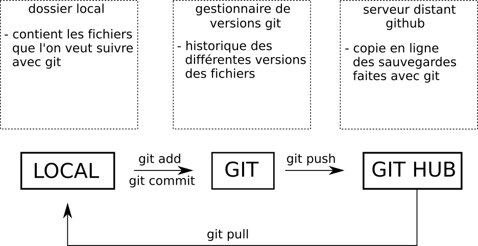

The goal of this little course is to get the basis of this tool, and its use.

## 1. Get started

### 1.1 Installation of git

**On Linux and MacOS :** To use git on Linux or MacOS, you’ll need to install the software with some command like :

```bash
$ sudo apt-get update
$ sudo apt-get install git
```

**On Windows** Install git for windows https://gitforwindows.org

Search *git bash* on your computer and open the terminal.

#### Create a link between your account and your computer with a SSH Key :

To make a secure link between your account and your computer, you need to generate a ssh key, and add it to your git account.

**First step :** create a ssh key

```bash
$ ssh-keygen -t rsa -b 4096 -C "my_email_github@email.com"
$ eval $(ssh-agent -s)

$ ssh-add ~/.ssh/id_rsa
```

You can add a password.

Save the key :

```bash
$ clip < ~/.ssh/id_rsa.pub
```

And you can past this key on your gitHub account :

- click on the bottom right
- SSH and GPG keys
- past key on the SSH emplacement

Well done you can continue.

**Second step :** save file from GitHub with *clone*

```bash
$ git clone git@github.com:StateOfTheR/finistR2019.git
```

#### Where is my project ?

- On one of my repository : Create a new repository on github
- Join an existing project : In a project, your can choose to have collaborators (settings/collaborators). To be a collaborator enable to push/pull on the project.

## 2. Basis commands

### 2.1 Add a file in your repository

Add a local document named “utilisation_GitHub.Rmd” in your git repository. You can display the differences between the local file and the current commit with git status.

```bash
$ git add utilisation_GitHub.Rmd
$ git status
```

### 2.2 Commit a file in your repository

Create a new commit containing the current contents of the index and the given log message describing the changes. The following command is used to record what has been changed in the document :

```bash
$ git commit -m "Add my latest version of the document"
```

The modified file is not on the server yet.

### 2.3 Synchronizing the file with the server

Upload your file to the server:

```bash
$ git push
```

To upload the files from the server to your local repository.

```bash
$ git pull
```

The different steps can be summarized by the figure displayed at the beginning.

## 3. Conflicts

A conflict will merge when 2 users has modified the same part (at the same time) of a file. For example, user A modifies part 1. of a document, add, commits and pushes the changes and user B modifies the same part of the document, add, commits and want to push before pulling the changements of user A. A conflict will then merge and user B will not be able to push its changes. \

When user B tries to push its changes, the following will happen:

```bash
git add FILE.EXTENSION
git commit -m "add changes of user B"
git push
```

An error message will then appear: `! [rejected] master -> master (non-fast-forward)`  
`error: failed to push some refs to 'REPOSITORY'`  
`hint: Updates were rejected because the tip of your current branch is behind`  
`hint: its remote counterpart. Integrate the remote changes (e.g.`  
`hint: 'git pull ...') before pushing again.`  
`hint: See the 'Note about fast-forwards' in 'git push --help' for details.`

IF user B now try to do pull, the following message will appear:

```bash
git pull
```

`CONFLICT (content): Merge conflict in FILE.extension` `Automatic merge failed; fix conflicts and then commit the result.`  
`(base) DIRECTORY/IN_LOCAL_COMPUTER$ git status`  
`On branch master`  
`Your branch and 'origin/master' have diverged,`  
`and have 1 and 1 different commits each, respectively.`  
`(use "git pull" to merge the remote branch into yours)`

To resolve the conflict the changes have to be merged, for this mergetool can be used:

```bash
git mergetool
```

In the local document of user B, the conclict will now be merged and user B will see his/her own changes **and** the changes of user A.

This will be indicated by:

`<<<<<<< HEAD`  
`my version (user B)`  
`=======`  
`the other version (user A)`  
`>>>>>>> 05009543925932...`

To resolve the conflict you have to resolve it manually, descide what version (B or A) to keep, or merge them both (manually). You can now commit and push your changes and the conflict is solved.

```bash
git add FILE.extension
git commit -m "added changes of user B and resolved conflict with user A"
git push
```